# Bellabeat

Sajid Hakim

12/5/2021

# Google Analytics Case Study – Bellabeat

## Background:

This is the capstone project for the Google Data Analytics course.  
The scenario consists of me, as a junior data analyst, working for Bellabeat. Bellabeat is a hi-tech maker of health-focused products for women with aspirations to become a bigger player in the global smart device market.

## Assignment:

Bellabeat’s cofounder, Urska Srsen has asked me to analyze smart device data from Fitbit to gain insight as to how consumers are using smart devices and use this knowledge to guide the marketing strategy of Bellabeat.

It should be noted that many others have already dissected this data for insights as part of their Capstone and most of the obvious and logical relationships have been explored. From my point of curiosity, I wanted to attempt at digging a little deeper into the data. For that purpose in addition to exploring the relationshps between steps or length of exercise time and calories I’ll be looking at weekly minutes of hi-intensity workout. Similarly, instead of looking at the relationship between length of sleep or depth of sleep and workout routine, I’m going to look at the time a participant is actually asleep in bed (instead of tossing and turning, waiting for sleep) out of the total time spent in bed. These may not reveal any eye-opening insights but would satisfy my curiosity and allow me to practice my recently acquired skills.

## Data:

### Source:

The dataset is one available from Kaggle and provided by Mobius. It consists of personal Fitbit tracking data of 33 eligible Fitbit users. It is public domain data and does not need any licenses for its use.

### Quality:

*Sample Age:* Data is from 2016 and as such a little dated. There may have been significant changes to the capabilities of smart devices as well as its penetration into the market and mode of usage since then.  
*Sample Size:* The sample size of 33 is barely large enough to deliver sound statistically valid results.  
*Sample Bias:* There is potential for sample bias because:  
a. Data is described as belonging to “eligible” Fitbit users. There is no explanation as to what criteria were used to define eligibility.  
b. Data belongs to those Fitbit users who have given permission for their personal data to be made public. As such, it is not a completely random sample.  
*Data Reliability:* The data comes from a public source with no way to confirm its accuracy or reliability.  
*Data Completeness:* Data represents Fitbit tracking of 33 participants over a period of 31 days but not all participants tracked all the same activities over the 31 day period as a result there are many gaps in the data. For example: only 24 participants tracked their sleep data and only 8 participants tracked their weights. Furthermore, the data does not include important variables such as age and height which are required to evaluate the efficacy of activity level being tracked.

## Setting up the Environment

Install and load packages * tidyverse * ggplot2  
* ggpubr  
* dpylr

```r
installed.packages("tidyverse")
```

```
##      Package LibPath Version Priority Depends Imports LinkingTo Suggests
##      Enhances License License_is_FOSS License_restricts_use OS_type Archs
##      MD5sum NeedsCompilation Built
```

```r
library(tidyverse)
```

```r
installed.packages("ggplot2")
```

```
##      Package LibPath Version Priority Depends Imports LinkingTo Suggests
##      Enhances License License_is_FOSS License_restricts_use OS_type Archs
##      MD5sum NeedsCompilation Built
```

```r
library(ggplot2)
installed.packages("ggpbr")
```

```
##      Package LibPath Version Priority Depends Imports LinkingTo Suggests
##      Enhances License License_is_FOSS License_restricts_use OS_type Archs
##      MD5sum NeedsCompilation Built
```

```r
library(ggpubr)
library(magrittr)
library(dplyr)
```

## Analysis Plan:

Two of the main reasons for exercising are:  
a) Weight loss (burning calories)  
I’m going to explore the relationship between Calories burned to Total Distance, Total Steps, Total Activity Time, and finally, Activity Speed (Total Distance/Total Activity Time) to see which is the best predictor. The results of this analysis will guide to further steps.  
b) Cardiovascular health  
Next, I referred to the American Heart Association website for objective measures and recommendations for daily activity [American Heart Association](https://www.heart.org/en/healthy-living/fitness/fitness-basics/aha-recs-for-physical-activity-in-adults). The website recommends 150 minutes of “heart-pumping” exercise per week. It also provides a chart for ideal heart-rate during this period but this rate varies by age. Not having participant age as one of the fields in my dataset, I have decided to use the field titled “VeryActiveMinutes” as a proxy to represent work-out time at the recommended heart-rate. I am going to see how many participants consistently work-out at the Very Active level for 150 minutes/week or more. The results of this analysis will guide to further steps.

In the next part of my analysis I will explore the impact of the exercise data on the participants well-being. In the absence of any other indicators, I will use the sleep data as a proxy to explore either a cause-and-effect or a correlation between exercise intensity and sleep quality. For this purpose I’m going to use the amount of time a person sleeps as a fraction of the total time spent in bed. This fraction is assumed to indicate how much “tossing and turning” a participant does before finally falling off to sleep.

## Data Cleansing & Transformation:

I will be using the dailyActivity_merged.csv data file which presents each participants daily steps, distance, and time spent at 4 possible activity levels:  
a. Very Active  
b. Fairly Active  
c. Lightly Active  
d. Sendentary

In order for ActivityDate to work well in R I have changed the format in the original Excel to YYYY-MM-DD before uploading to RStudio.

```r
daily_activity <- read.csv("dailyActivity_merged.csv")
nrow(daily_activity)
```

```
## [1] 940
```

```r
head(daily_activity)
```

```
##           Id ActivityDate TotalSteps TotalDistance TrackerDistance
## 1 1503960366   2016-04-12      13162          8.50            8.50
## 2 1503960366   2016-04-13      10735          6.97            6.97
## 3 1503960366   2016-04-14      10460          6.74            6.74
## 4 1503960366   2016-04-15       9762          6.28            6.28
## 5 1503960366   2016-04-16      12669          8.16            8.16
## 6 1503960366   2016-04-17       9705          6.48            6.48
##   LoggedActivitiesDistance VeryActiveDistance ModeratelyActiveDistance
## 1                        0               1.88                     0.55
## 2                        0               1.57                     0.69
## 3                        0               2.44                     0.40
## 4                        0               2.14                     1.26
## 5                        0               2.71                     0.41
## 6                        0               3.19                     0.78
##   LightActiveDistance SedentaryActiveDistance VeryActiveMinutes
## 1                6.06                       0                25
## 2                4.71                       0                21
## 3                3.91                       0                30
## 4                2.83                       0                29
## 5                5.04                       0                36
## 6                2.51                       0                38
##   FairlyActiveMinutes LightlyActiveMinutes SedentaryMinutes Calories
## 1                  13                  328              728     1985
## 2                  19                  217              776     1797
## 3                  11                  181             1218     1776
## 4                  34                  209              726     1745
## 5                  10                  221              773     1863
## 6                  20                  164              539     1728
```

```r
glimpse(daily_activity)
```

```
## Rows: 940
## Columns: 15
## $ Id                       <dbl> 1503960366, 1503960366, 1503960366, 150396036…
## $ ActivityDate             <chr> "2016-04-12", "2016-04-13", "2016-04-14", "20…
## $ TotalSteps               <int> 13162, 10735, 10460, 9762, 12669, 9705, 13019…
## $ TotalDistance            <dbl> 8.50, 6.97, 6.74, 6.28, 8.16, 6.48, 8.59, 9.8…
## $ TrackerDistance          <dbl> 8.50, 6.97, 6.74, 6.28, 8.16, 6.48, 8.59, 9.8…
## $ LoggedActivitiesDistance <dbl> 0, 0, 0, 0, 0, 0, 0, 0, 0, 0, 0, 0, 0, 0, 0, …
## $ VeryActiveDistance       <dbl> 1.88, 1.57, 2.44, 2.14, 2.71, 3.19, 3.25, 3.5…
## $ ModeratelyActiveDistance <dbl> 0.55, 0.69, 0.40, 1.26, 0.41, 0.78, 0.64, 1.3…
## $ LightActiveDistance      <dbl> 6.06, 4.71, 3.91, 2.83, 5.04, 2.51, 4.71, 5.0…
## $ SedentaryActiveDistance  <dbl> 0, 0, 0, 0, 0, 0, 0, 0, 0, 0, 0, 0, 0, 0, 0, …
## $ VeryActiveMinutes        <int> 25, 21, 30, 29, 36, 38, 42, 50, 28, 19, 66, 4…
## $ FairlyActiveMinutes      <int> 13, 19, 11, 34, 10, 20, 16, 31, 12, 8, 27, 21…
## $ LightlyActiveMinutes     <int> 328, 217, 181, 209, 221, 164, 233, 264, 205, …
## $ SedentaryMinutes         <int> 728, 776, 1218, 726, 773, 539, 1149, 775, 818…
## $ Calories                 <int> 1985, 1797, 1776, 1745, 1863, 1728, 1921, 203…
```

```r
#Convert ActivityDate column from character to date
daily_activity$ActivityDate = as.Date(daily_activity$ActivityDate)
glimpse(daily_activity)
```

```
## Rows: 940
## Columns: 15
## $ Id                       <dbl> 1503960366, 1503960366, 1503960366, 150396036…
## $ ActivityDate             <date> 2016-04-12, 2016-04-13, 2016-04-14, 2016-04-…
## $ TotalSteps               <int> 13162, 10735, 10460, 9762, 12669, 9705, 13019…
## $ TotalDistance            <dbl> 8.50, 6.97, 6.74, 6.28, 8.16, 6.48, 8.59, 9.8…
## $ TrackerDistance          <dbl> 8.50, 6.97, 6.74, 6.28, 8.16, 6.48, 8.59, 9.8…
## $ LoggedActivitiesDistance <dbl> 0, 0, 0, 0, 0, 0, 0, 0, 0, 0, 0, 0, 0, 0, 0, …
## $ VeryActiveDistance       <dbl> 1.88, 1.57, 2.44, 2.14, 2.71, 3.19, 3.25, 3.5…
## $ ModeratelyActiveDistance <dbl> 0.55, 0.69, 0.40, 1.26, 0.41, 0.78, 0.64, 1.3…
## $ LightActiveDistance      <dbl> 6.06, 4.71, 3.91, 2.83, 5.04, 2.51, 4.71, 5.0…
## $ SedentaryActiveDistance  <dbl> 0, 0, 0, 0, 0, 0, 0, 0, 0, 0, 0, 0, 0, 0, 0, …
## $ VeryActiveMinutes        <int> 25, 21, 30, 29, 36, 38, 42, 50, 28, 19, 66, 4…
## $ FairlyActiveMinutes      <int> 13, 19, 11, 34, 10, 20, 16, 31, 12, 8, 27, 21…
## $ LightlyActiveMinutes     <int> 328, 217, 181, 209, 221, 164, 233, 264, 205, …
## $ SedentaryMinutes         <int> 728, 776, 1218, 726, 773, 539, 1149, 775, 818…
## $ Calories                 <int> 1985, 1797, 1776, 1745, 1863, 1728, 1921, 203…
```

Check to see if total time for any entry > 1440 minutes (total mins in a day)

```r
daily_activity <- mutate(daily_activity, total_time = VeryActiveMinutes + FairlyActiveMinutes
                         + LightlyActiveMinutes + SedentaryMinutes)
error_file <- filter(daily_activity, total_time > 1440)
nrow(error_file)
```

```
## [1] 0
```

Zero rows in error_file indicates no rows in daily_activity > 1440 minutes.

Although there are some participants with missing data for certain days, I have decided to not exclude those participants because I’m not calculating any statistics at this point and I would like to see any trends from all available data.

We will be exploring “speed” of activity defined as the ratio of total distance covered by steps and total active time spent

```r
#Add up all activity minutes
daily_activity <- mutate(daily_activity, active_time = total_time - SedentaryMinutes)

#Calculate activity average speed (total activity distance/total activity time)
daily_activity <- mutate(daily_activity, avg_speed = TotalDistance/active_time)
```

Let us find out what is, on average, the best predictor of calories burned

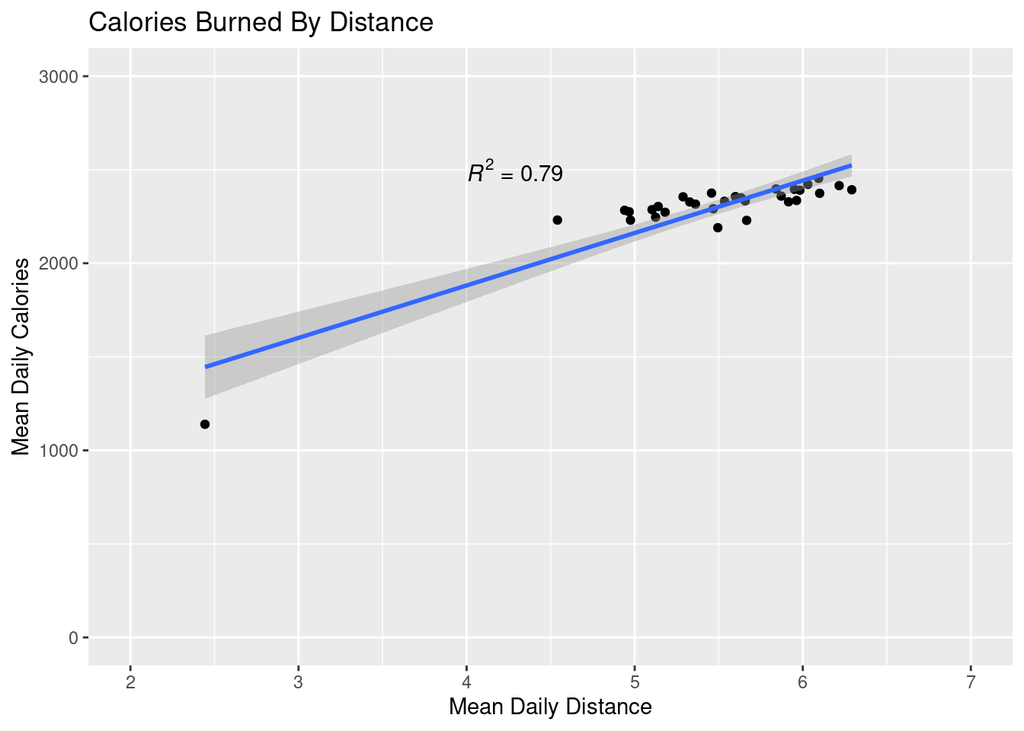

```r
#Calculate Daily Averages
mean_of_data <- daily_activity %>% group_by(ActivityDate) %>%
  summarise(mean_daily_distance=mean(TotalDistance),
            mean_daily_steps=mean(TotalSteps), mean_daily_time=mean(active_time),
            mean_daily_calories=mean(Calories))

#Plot Distance against the mean daily calories burned
ggplot(data=mean_of_data) +
  geom_point(mapping=aes(x=mean_daily_distance, y = mean_daily_calories))+
  geom_smooth(method="lm", aes(x=mean_daily_distance, y = mean_daily_calories))+
  stat_regline_equation(label.x=4, label.y=2500,
                        aes(x=mean_daily_distance, y = mean_daily_calories, label=..rr.label..))+
  labs(title="Calories Burned By Distance")+
  xlab("Mean Daily Distance") + ylab("Mean Daily Calories")+
  xlim(2,7)+ ylim(0,3000)
```

One of the points is an obvious outlier. Let’s take a closer look at our dataset. The data for May 12th seem excessively low and not representative of the sample population. I will exclude from further analysis.

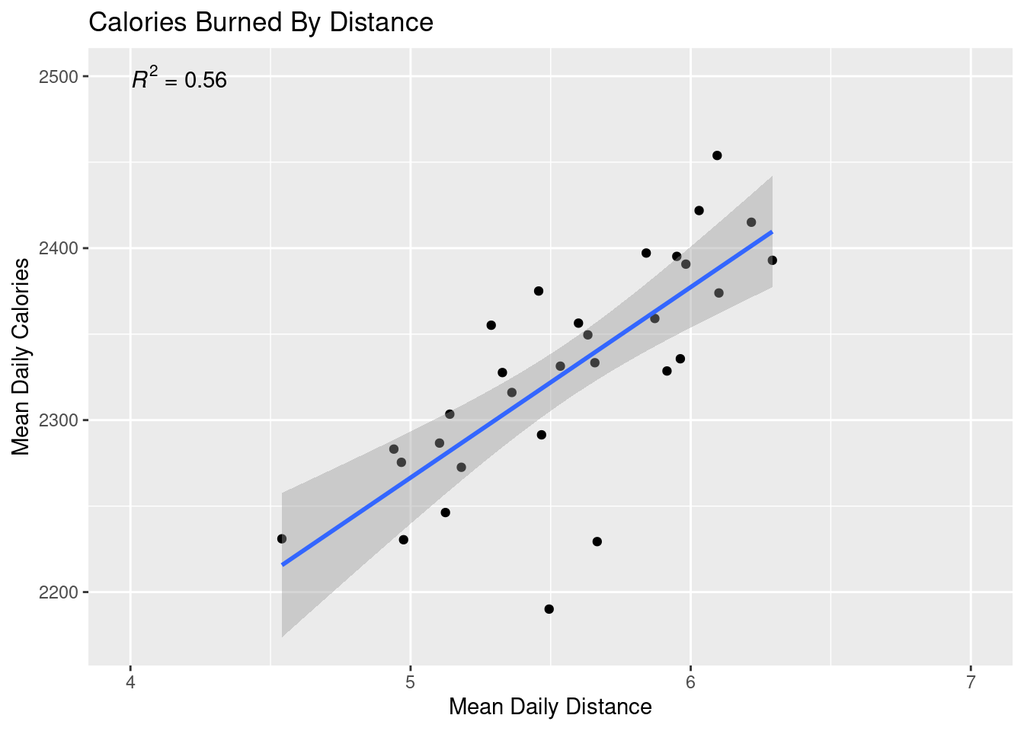

```r
mean_of_data <- filter(mean_of_data, mean_of_data$ActivityDate!="2016-05-12")

mean_of_data <- mutate(mean_of_data, mean_daily_speed=
                         mean_daily_distance/mean_daily_time)

#Plot Distance against the mean daily calories burned
ggplot(data=mean_of_data) +
  geom_point(mapping=aes(x=mean_daily_distance, y = mean_daily_calories))+
  geom_smooth(method="lm", aes(x=mean_daily_distance, y = mean_daily_calories))+
  stat_regline_equation(label.x=4, label.y=2500,
                        aes(x=mean_daily_distance, y = mean_daily_calories, label=..rr.label..))+
  labs(title="Calories Burned By Distance")+
  xlab("Mean Daily Distance") + ylab("Mean Daily Calories")+
  xlim(4,7)
```

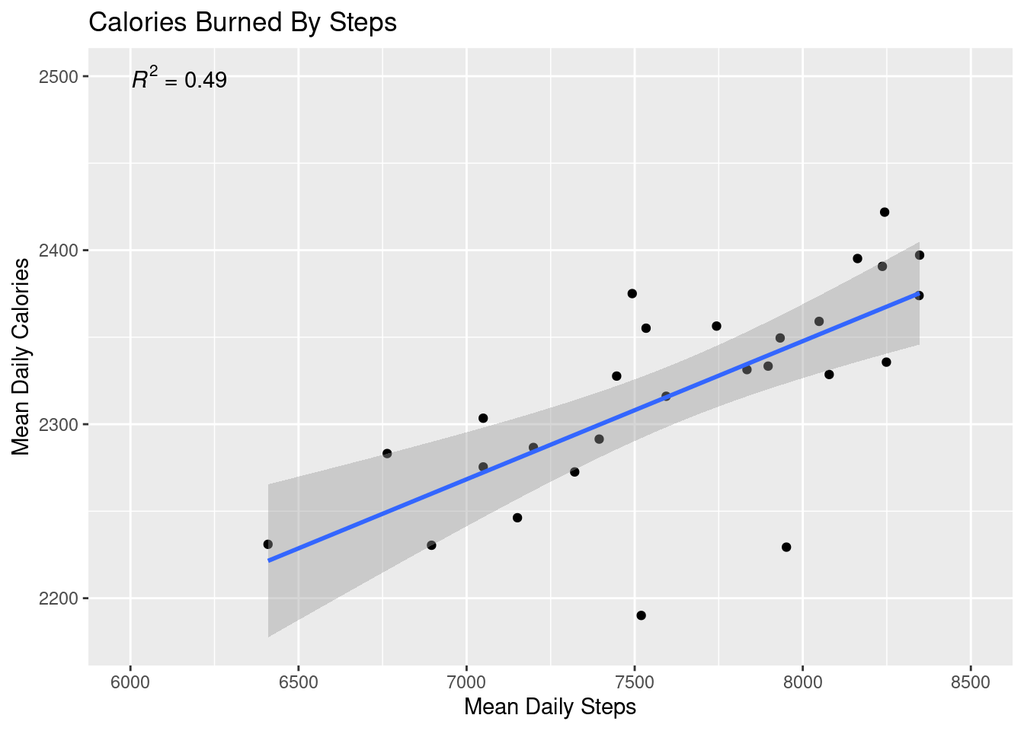

```r
#Plot Steps against the mean daily calories burned
ggplot(data=mean_of_data) +
  geom_point(mapping=aes(x=mean_daily_steps, y = mean_daily_calories))+
  geom_smooth(method="lm", aes(x=mean_daily_steps, y = mean_daily_calories))+
  stat_regline_equation(label.x=6000, label.y=2500,
                        aes(x=mean_daily_steps, y = mean_daily_calories, label=..rr.label..))+
  labs(title="Calories Burned By Steps")+
  xlab("Mean Daily Steps") + ylab("Mean Daily Calories")+
  xlim(6000,8500)
```

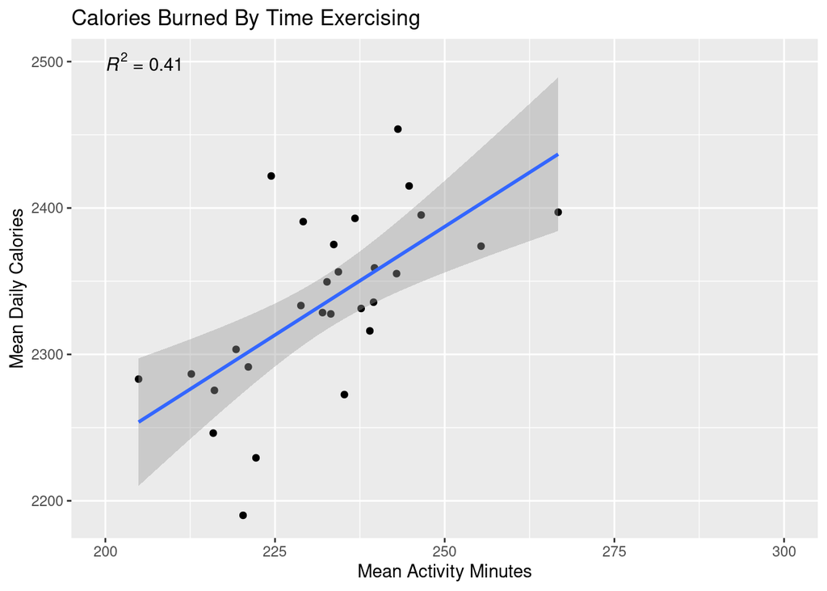

```r
#Plot Activity Time against the mean daily calories burned
ggplot(data=mean_of_data) +
  geom_point(mapping=aes(x=mean_daily_time, y = mean_daily_calories))+
  geom_smooth(method="lm", aes(x=mean_daily_time, y = mean_daily_calories))+
  stat_regline_equation(label.x=200, label.y=2500,
                        aes(x=mean_daily_time, y = mean_daily_calories, label=..rr.label..))+
  labs(title="Calories Burned By Time Exercising")+
  xlab("Mean Activity Minutes") + ylab("Mean Daily Calories")+
  xlim(200,300)
```

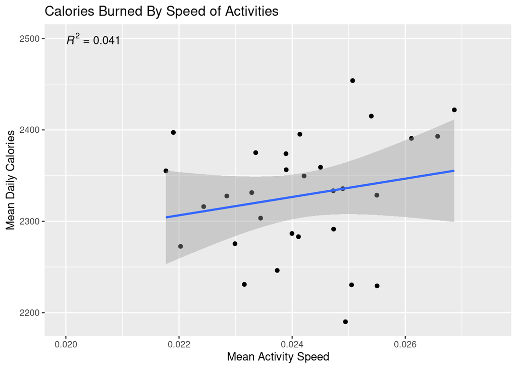

```r
#Plot Speed of Activity against the mean daily calories burned
ggplot(data=mean_of_data) +
  geom_point(mapping=aes(x=mean_daily_speed, y = mean_daily_calories))+
  geom_smooth(method="lm", aes(x=mean_daily_speed, y = mean_daily_calories))+
  stat_regline_equation(label.x=0.02, label.y=2500,
                        aes(x=mean_daily_speed, y = mean_daily_calories, label=..rr.label..))+
  labs(title="Calories Burned By Speed of Activities")+
  xlab("Mean Activity Speed") + ylab("Mean Daily Calories")+
  xlim(0.02,0.0275)
```

None of the matrices offer a very strong correlation coefficient but distance covered offers the best correlation with carlories burned.

Explore how activity varies by day of week

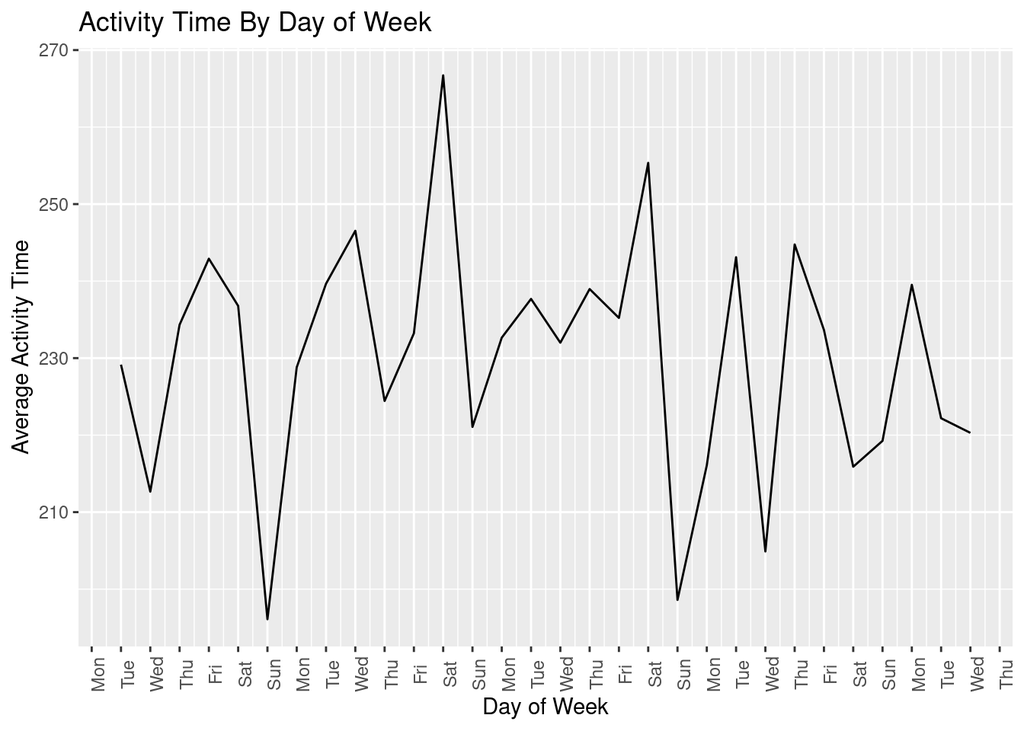

```r
#Convert ActivityDate to weekdays
mean_of_data$week_day = weekdays(mean_of_data$ActivityDate)

#Plot Amount of time Exercised against the day of week
ggplot(data = mean_of_data)+
  geom_line(mapping=aes(x=ActivityDate, y=mean_daily_time))+
  labs(title="Activity Time By Day of Week")+
  xlab("Day of Week")  + ylab("Average Activity Time")+
  scale_x_date(date_breaks = "day",
               date_labels = "%a")+
  theme(axis.text.x=element_text(angle=90))
```

Interestingly, it seems active time generally highest on Saturdays and lowest on Sundays.

A Quick Check of trends for Total Distance:

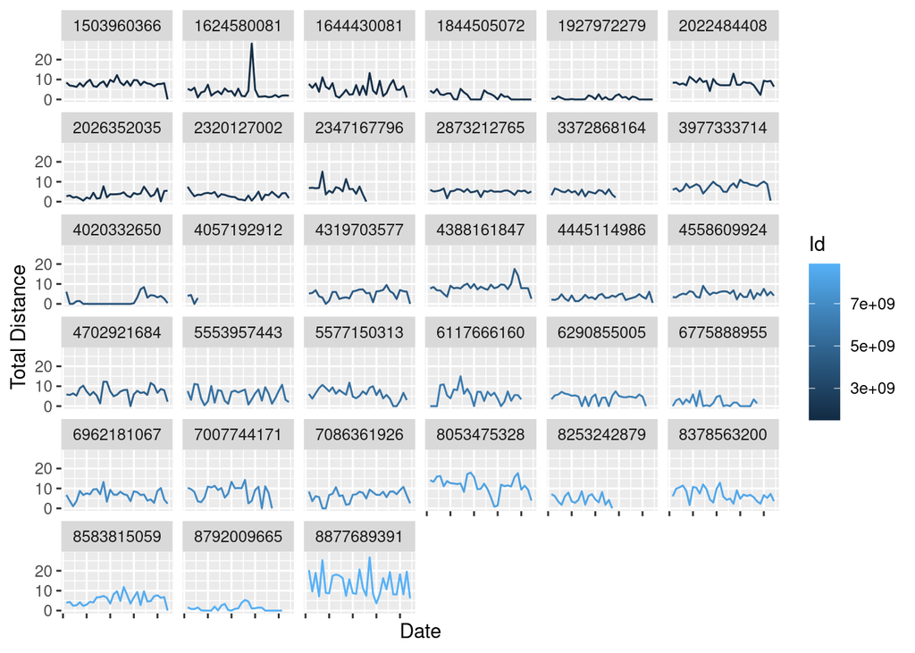

```r
ggplot(data=daily_activity)+
  geom_line(mapping=aes(x=ActivityDate, y=TotalDistance, col=Id))+
  xlab("Date") + ylab("Total Distance") +
  theme(axis.text.x=element_blank()) +
  facet_wrap(~Id)
```

Check for trends in the time of activity.

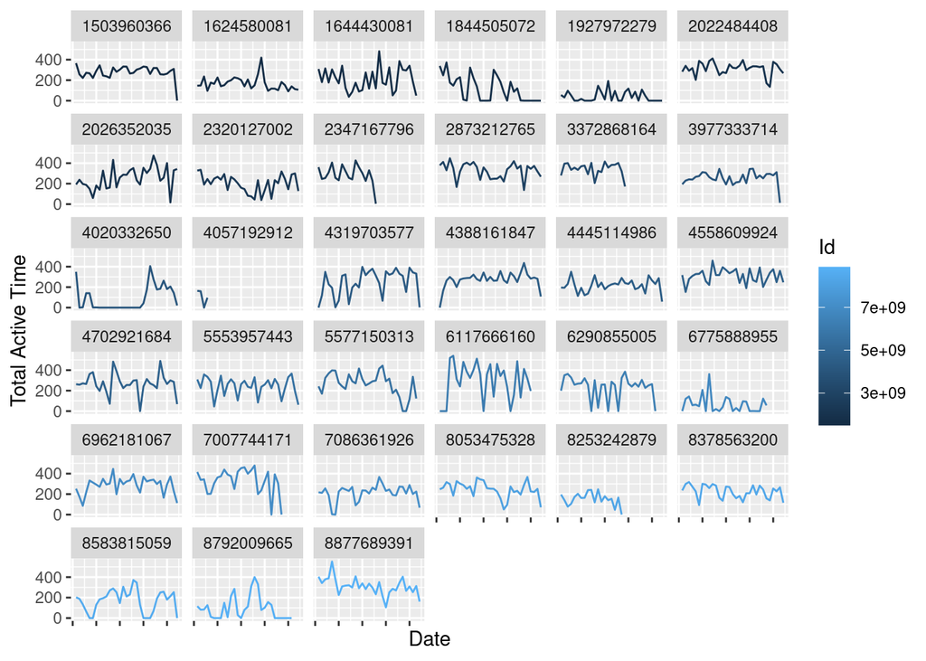

```r
#plot total daily activity time for each participant
ggplot(data=daily_activity)+
  geom_line(mapping=aes(x=ActivityDate, y=active_time, col=Id))+
  xlab("Date") + ylab("Total Active Time") +
  theme(axis.text.x=element_blank()) +
  facet_wrap(~Id)
```

Check for trends in the speed of activity.

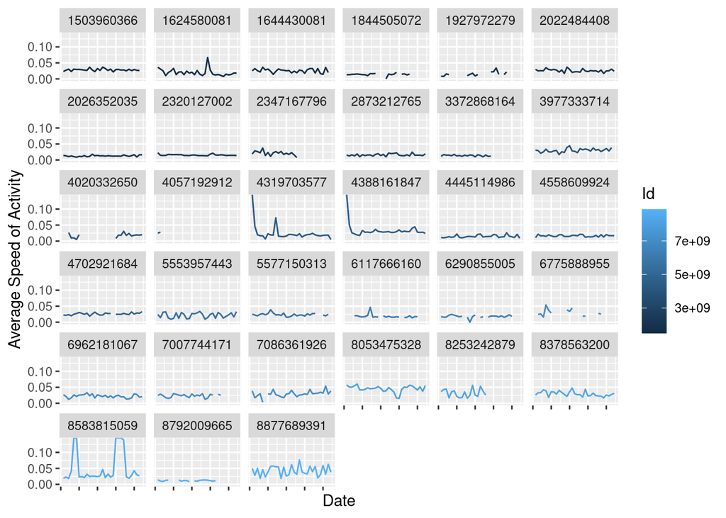

```r
ggplot(data = daily_activity) +
  geom_line(mapping = aes(x=ActivityDate, y=avg_speed, col=Id))+
  xlab("Date") + ylab("Average Speed of Activity")+
  theme(axis.text.x = element_blank()) +
  facet_wrap(~Id)
```

The plots show most of the participants are inconsistent in their activity and are not able to sustain a consistent level.

It would be interesting to see if the activities were to be divided into 7-day blocks, whether the participants meet the American Heart Association guideline for 150 minutes of heart-pumping exercise (VeryActiveMinutes) every week.

```r
#Split the daily_activity file into chunks of 7-day file
very_active_week1 <- filter(daily_activity, ActivityDate <= '2016-04-18')
very_active_week2 <- filter(daily_activity, ActivityDate > '2016-04-18'
                             & ActivityDate <= '2016-04-25')
very_active_week3 <- filter(daily_activity, ActivityDate > '2016-04-25'
                            & ActivityDate <= '2016-05-01')
very_active_week4 <- filter(daily_activity, ActivityDate > '2016-05-01'
                            & ActivityDate <= '2016-05-08')
very_active_no_use <- filter(daily_activity, ActivityDate > '2016-05-08')

#Check if total rows of weekly files adds up to total rows of original data file
nrow(very_active_week1) + nrow(very_active_week2) + nrow(very_active_week3) + nrow(very_active_week4) + nrow(very_active_no_use) - nrow(daily_activity)
```

```
## [1] 0
```

Satisfied no rows are missing.

```r
#Find the total weekly VeryActiveMinutes for each participant
week1_veryactive_sum <- aggregate(VeryActiveMinutes~Id, very_active_week1, sum)
week2_veryactive_sum <- aggregate(VeryActiveMinutes~Id, very_active_week2, sum)
week3_veryactive_sum <- aggregate(VeryActiveMinutes~Id, very_active_week3, sum)
week4_veryactive_sum <- aggregate(VeryActiveMinutes~Id, very_active_week4, sum)
```

View the weekly VeryActiveMinutes as a histogram to see how many participants meet the American Heart Association guidelines

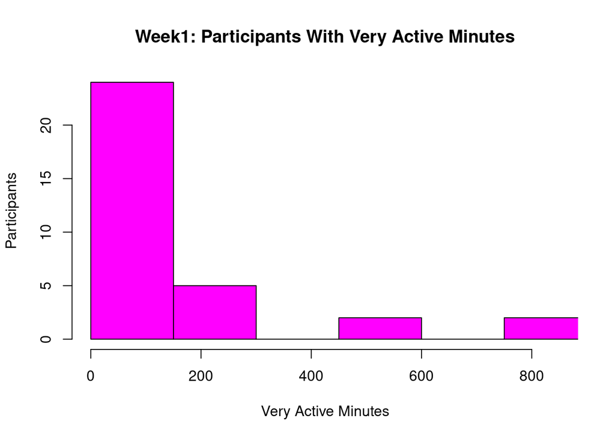

```r
#week1
hist(week1_veryactive_sum$VeryActiveMinutes,
     main = "Week1: Participants With Very Active Minutes",
     xlab = "Very Active Minutes",
     ylab = "Participants",
     xlim = c(0,850),
     breaks = c(0,150,300,450,600,750,900),
     col = "magenta"
     )
```

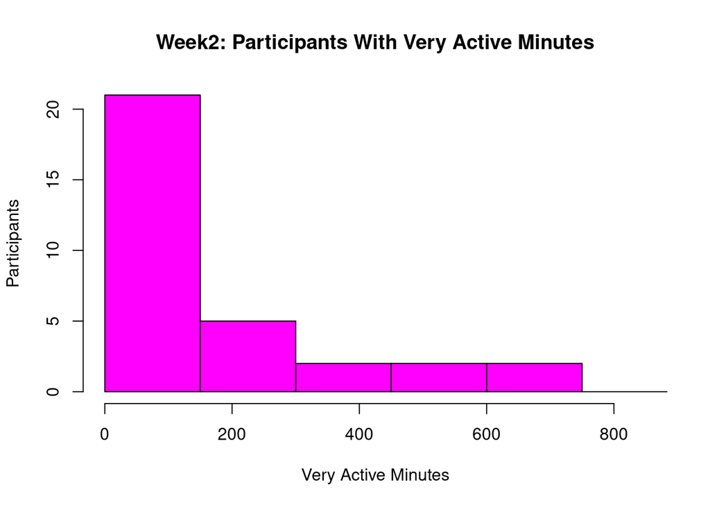

```r
#week2
hist(week2_veryactive_sum$VeryActiveMinutes,
     main = "Week2: Participants With Very Active Minutes",
     xlab = "Very Active Minutes",
     ylab = "Participants",
     xlim = c(0,850),
     breaks = c(0,150,300,450,600,750,900),
     col = "magenta"
)
```